# Gene-regulatory network of cardiomyocyte remodeling after myocardial infarction

Compiled: October 29, 2026

During this tutorial, we will integrate the snRNA-seq and snATAC-seq data generated from the human heart samples after myocardial infarction. The integrated data will be used as input for inferring gene regulatory network.

We first download the required data. In this case, we need two Seurat objects with each one corresponding to snRNA-seq and snATAC-seq respectively. The snRNA-seq object includes gene expression data of cardiomyocytes and the snATAC-seq object includes their chromatin accessibility profiles. Additionally, we also need a gene activity matrix for data integration. This matrix was estimated from the snATAC-seq data by using the [ArchR](https://www.archrproject.com/) package. The script for cleaning the data and preparing these objects is found [here](https://costalab.ukaachen.de/open_data/scMEGA/Cardiomyocyte/01_prepare_data.html).

Run the following commands to download the data:

```r
if(!dir.exists('./Cardiomyocyte')){
    dir.create('./Cardiomyocyte')
}

if (!file.exists('./Cardiomyocyte/snRNA.rds'))
    download.file('https://costalab.ukaachen.de/open_data/scMEGA/Cardiomyocyte/snRNA.rds',
                  './Cardiomyocyte/snRNA.rds', mode = 'wb')

if (!file.exists('./Cardiomyocyte/snATAC.rds'))
    download.file('https://costalab.ukaachen.de/open_data/scMEGA/Cardiomyocyte/snATAC.rds',
                  './Cardiomyocyte/snATAC.rds', mode = 'wb')

if (!file.exists('./Cardiomyocyte/gene.activity.rds'))
    download.file('https://costalab.ukaachen.de/open_data/scMEGA/Cardiomyocyte/gene.activity.rds',
                  './Cardiomyocyte/gene.activity.rds', mode = 'wb')
```

Next, we load all necessary packages:

```r
suppressMessages(library(ArchR))
suppressMessages(library(Seurat))
suppressMessages(library(Signac))
suppressMessages(library(scMEGA))
suppressMessages(library(harmony))
suppressMessages(library(Nebulosa))
suppressMessages(library(ggplot2))
suppressMessages(library(dplyr))
suppressMessages(library(JASPAR2020))
suppressMessages(library(TFBSTools))
suppressMessages(library(igraph))
suppressMessages(library(ggraph))
suppressMessages(library(BSgenome.Hsapiens.UCSC.hg38))
```

## Data integration

Let’s load the data into memory and see how they look like

To reduce computational requirements, this tutorial uses reproducible stratified downsampling of the original RNA and ATAC datasets. The resulting analysis demonstrates the complete scMEGA workflow, but the inferred trajectories and regulatory networks may differ from those obtained using the full dataset.

```r
obj.rna <- readRDS("./Cardiomyocyte/snRNA.rds")
obj.atac <- readRDS("./Cardiomyocyte/snATAC.rds")
gene.activity <- readRDS("./Cardiomyocyte/gene.activity.rds")

stratified_cells <- function(object, n, seed) {
  cells <- colnames(object)
  metadata <- object[[]][cells, c("patient_group", "patient_region_id"), drop = FALSE]
  if (anyNA(metadata))
    stop("Sampling strata contain missing patient_group or patient_region_id values")
  if (n >= length(cells))
    return(cells)

  strata <- paste(metadata$patient_group, metadata$patient_region_id, sep = "::")
  counts <- table(strata)
  ideal <- n * as.numeric(counts) / sum(counts)
  take <- floor(ideal)
  remainder <- n - sum(take)
  if (remainder > 0L) {
    priority <- order(ideal - take, names(counts), decreasing = TRUE)
    take[priority[seq_len(remainder)]] <- take[priority[seq_len(remainder)]] + 1L
  }
  names(take) <- names(counts)

  set.seed(seed)
  selected <- unlist(lapply(names(take), function(group) {
    sample(cells[strata == group], take[[group]], replace = FALSE)
  }), use.names = FALSE)
  # Keep original object ordering after deterministic selection.
  cells[cells %in% selected]
}

original.rna.cells <- colnames(obj.rna)
original.atac.cells <- colnames(obj.atac)
if (!identical(colnames(gene.activity), original.atac.cells)) {
  if (!setequal(colnames(gene.activity), original.atac.cells))
    stop("GeneActivity columns do not match ATAC cells")
  gene.activity <- gene.activity[, original.atac.cells, drop = FALSE]
}

if (USE_DOWNSAMPLING) {
  selected.rna.cells <- stratified_cells(obj.rna, N_RNA_CELLS, SAMPLING_SEED)
  selected.atac.cells <- stratified_cells(obj.atac, N_ATAC_CELLS, SAMPLING_SEED + 1L)
  obj.rna <- subset(obj.rna, cells = selected.rna.cells)
  obj.atac <- subset(obj.atac, cells = selected.atac.cells)
  gene.activity <- gene.activity[, selected.atac.cells, drop = FALSE]
  stopifnot(
    identical(colnames(obj.rna), selected.rna.cells),
    identical(colnames(obj.atac), selected.atac.cells),
    identical(colnames(gene.activity), selected.atac.cells)
  )
  writeLines(selected.rna.cells, "./Cardiomyocyte/sampled-rna-cells.txt")
  writeLines(selected.atac.cells, "./Cardiomyocyte/sampled-atac-cells.txt")
  gc(full = TRUE)
}
```

```
##              used   (Mb) gc trigger    (Mb) limit (Mb)   max used    (Mb)
## Ncells   14663718  783.2   27863962  1488.1         NA   17491005   934.2
## Vcells 1056110197 8057.5 3091629866 23587.3      65536 3024109451 23072.2
```

```r
sampling.summary <- list(
  original = c(RNA = length(original.rna.cells), ATAC = length(original.atac.cells)),
  selected = c(RNA = ncol(obj.rna), ATAC = ncol(obj.atac)),
  rna.by.group = table(obj.rna$patient_group),
  atac.by.group = table(obj.atac$patient_group)
)
sampling.summary
```

```
## $original
##   RNA  ATAC
## 63161 19859
##
## $selected
##   RNA  ATAC
## 40000  8000
##
## $rna.by.group
##
## fibrotic ischemic myogenic
##     2672     2688    34640
##
## $atac.by.group
##
## fibrotic ischemic myogenic
##     1855      303     5842
```

The current compatibility layer supports the legacy RNA assay while preserving the ATAC `ChromatinAssay`, including its genomic ranges and metadata.

```r
obj.rna
```

```
## An object of class Seurat
## 28933 features across 40000 samples within 1 assay
## Active assay: RNA (28933 features, 2000 variable features)
##  3 layers present: counts, data, scale.data
##  4 dimensional reductions calculated: pca, harmony, umap, umap_harmony
```

```r
obj.atac
```

```
## An object of class Seurat
## 182116 features across 8000 samples within 1 assay
## Active assay: ATAC (182116 features, 0 variable features)
##  2 layers present: counts, data
##  3 dimensional reductions calculated: harmony, umap, umap_harmony
```

The source objects contain 63,161 RNA and 19,859 ATAC cells. The published example uses the fixed stratified sample above so that exact CCA can complete on a 64 GB workstation while retaining every patient-region stratum and all three patient groups. RNA and ATAC are unpaired and are sampled independently; GeneActivity always follows the selected ATAC cells in the same order. This resource-bounded example is not numerically identical to the full-data analysis.

We now visualize the sampled data as colored by patients. Note that here we used the UMAP embedding generated from batch-corrected low-dimensional space so that no batch effects are observed from the 2D visualization.

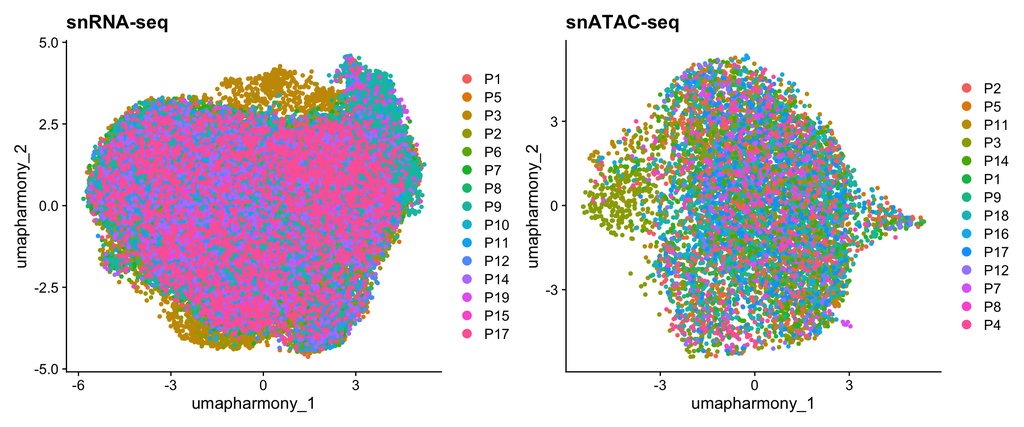

```r
p1 <- DimPlot(obj.rna, pt.size = 1, reduction = "umap_harmony") +
    ggtitle("snRNA-seq")

p2 <- DimPlot(obj.atac, pt.size = 1, reduction = "umap_harmony") +
    ggtitle("snATAC-seq")

p1 + p2
```

### Co-embedding

First, we need to project the data into a common low-dimensional space. This is done by using the CCA method from [Seurat](https://satijalab.org/seurat/). To this end, we have wrapped several functions from Seurat into a single function *CoembedData*.

```r
obj.coembed <- CoembedData(
  obj.rna,
  obj.atac,
  gene.activity,
  weight.reduction = "harmony",
  verbose = FALSE
)
```

```
## Find 19026 common genes between ATAC and RNA
```

```
## Subset ATAC and RNA data
```

```
## Normalize gene activity score for ATAC data
```

```
## Performing data integration using Seurat...
```

```
## Finding integration vectors
```

```
## Finding integration vector weights
```

```
## Transfering 19026 features onto reference data
```

```
## Coemebdding the data...
```

```
## Centering data matrix
```

We next visualize the snRNA-seq and snATAC-seq in this shared UMAP space. The cells are colored by patients or modalities.

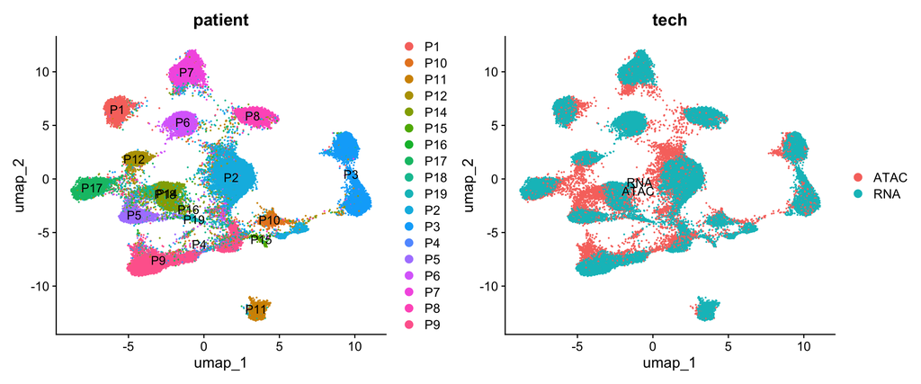

```r
p1 <- DimPlot(obj.coembed, group.by = "patient", shuffle = TRUE, label = TRUE)
p2 <- DimPlot(obj.coembed, group.by = "tech", shuffle = TRUE, label = TRUE)

p1 + p2
```

The batch effects between patients, regions and modalities are quite clear. So next we use [Harmony](https://www.nature.com/articles/s41592-019-0619-0) to perform batch correction and generate a new UMAP embedding.

```r
obj.coembed <- RunHarmony(obj.coembed,
                          group.by.vars = c("patient", "region", "tech"),
                          reduction.use = "pca",
                          dims.use = 1:30,
                          project.dim = FALSE,
                          plot_convergence = FALSE)
```

```
## Transposing data matrix
```

```
## Using automatic lambda estimation
```

```
## Thetas: 2
```

```
## Initializing state using k-means centroids initialization
```

```
## Initializing centroids
```

```
## Harmony 1/10
```

```
## Harmony 2/10
```

```
## Harmony 3/10
```

```
## Harmony 4/10
```

```
## Harmony 5/10
```

```
## Harmony 6/10
```

```
## Harmony 7/10
```

```
## Harmony 8/10
```

```
## Harmony 9/10
```

```
## Harmony converged after 9 iterations
```

```r
obj.coembed <- RunUMAP(
  obj.coembed,
  dims = 1:30,
  reduction = 'harmony',
  reduction.name = "umap_harmony",
  reduction.key = 'umapharmony_',
  verbose = FALSE,
  min.dist = 0.4
)
```

We can plot the data again

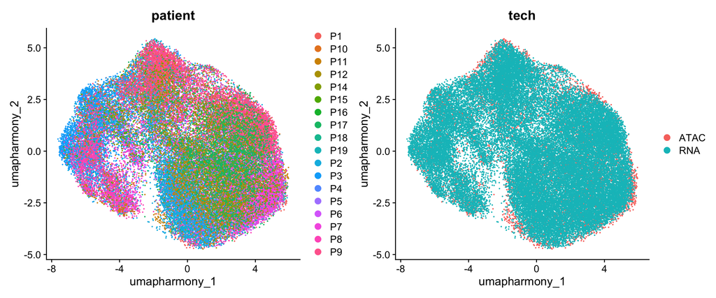

```r
p1 <-
  DimPlot(obj.coembed, group.by = "patient", reduction = "umap_harmony")
p2 <-
  DimPlot(obj.coembed, group.by = "tech", reduction = "umap_harmony")

p1 + p2
```

From the new UMAP embedding, we can observe that after batch-correction, cells from different patients, regions, and modalities are well mixed.

### Sub-clustering

We next perform sub-clustering to identify different populations in our multi-omic cardiomyocyte data. To further control the data quality, here we use a two-round approach to remove low-quality cells. We first use a high resolution to obtain a larger set of clusters.

```r
obj.coembed <- FindNeighbors(obj.coembed, reduction = "harmony", dims = 1:30)
```

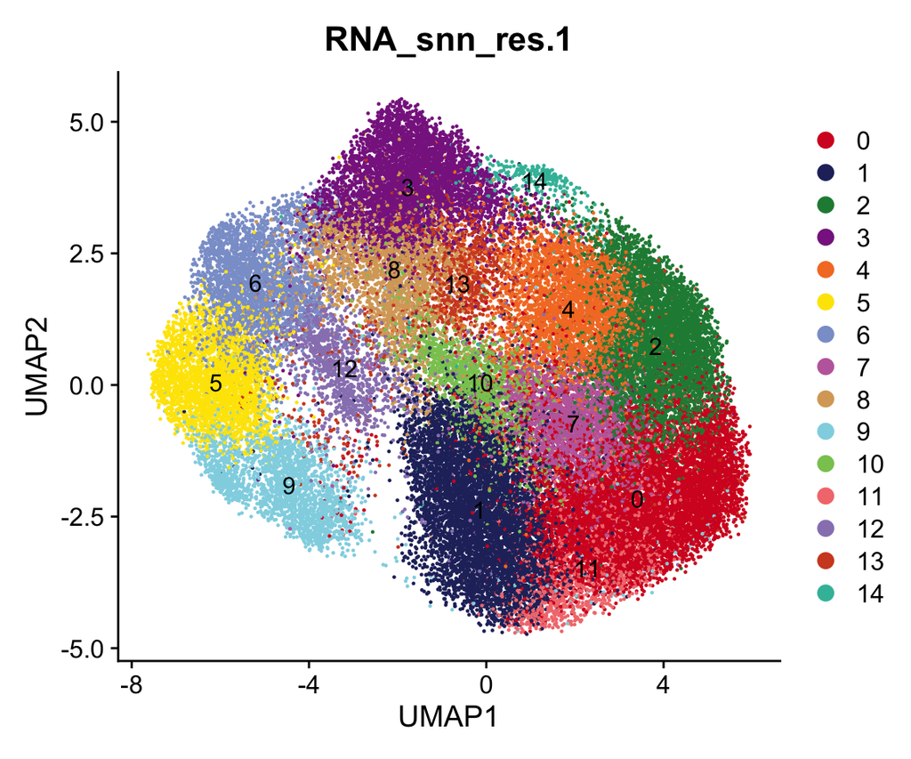

```r
obj.coembed <- FindClusters(obj.coembed, resolution = 1, verbose = FALSE)

cols <- ArchR::paletteDiscrete(obj.coembed[[]][, "RNA_snn_res.1"])

p <- DimPlot(obj.coembed, group.by = "RNA_snn_res.1", label = TRUE,
             reduction = "umap_harmony", shuffle = TRUE) +
    scale_color_manual(values = cols) +
    xlab("UMAP1") + ylab("UMAP2")

p
```

We can use the function *CellPropPlot* to visualize the cell propotion across all patients.

```r
cols <- ArchR::paletteDiscrete(obj.coembed[[]][, "patient_region_id"])
```

```
## Length of unique values greater than palette, interpolating..
```

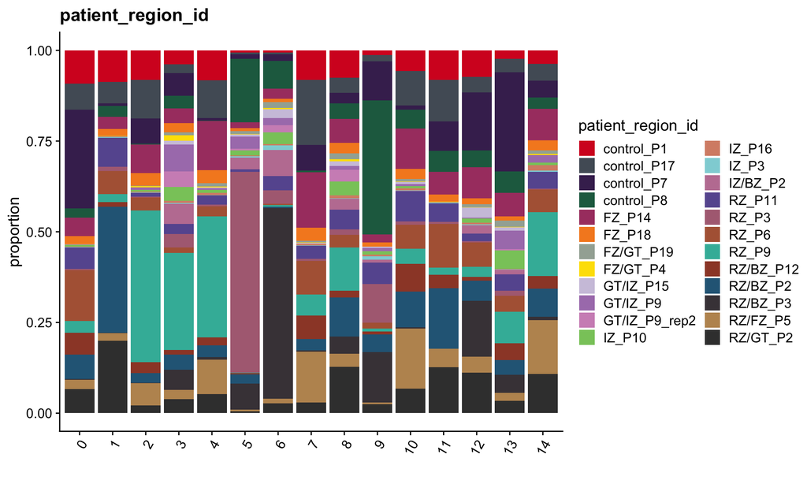

```r
p1 <- CellPropPlot(obj.coembed,
                   group.by = "patient_region_id",
                   prop.in = "RNA_snn_res.1",
                  cols = cols)
p2 <- CellPropPlot(obj.coembed,
                   group.by = "tech",
                   prop.in = "RNA_snn_res.1")

p1
```

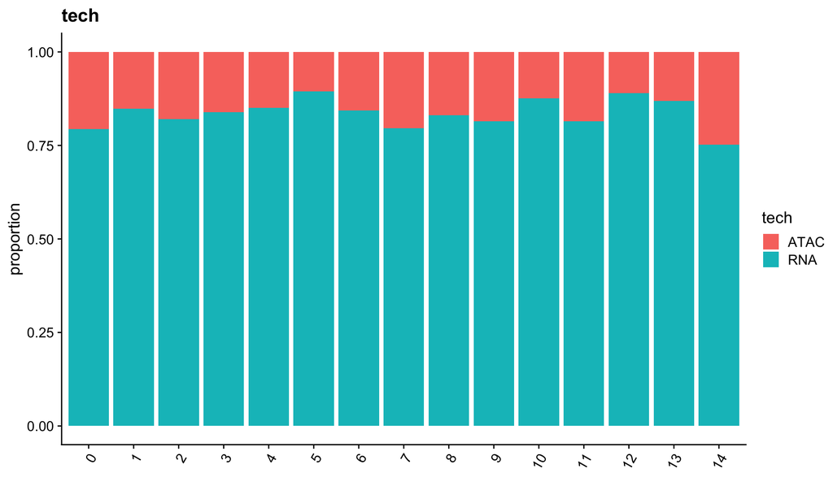

```r
p2
```

Next, we identify the markers for each cluster and visualize the top 3.

```r
all.markers <- FindAllMarkers(obj.coembed,
                              only.pos = TRUE,
                              min.pct = 0.5, logfc.threshold = 0.5)
```

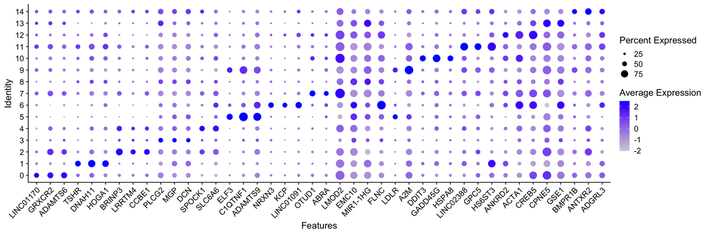

```r
df <- all.markers %>%
    group_by(cluster) %>%
    slice_max(n = 3, order_by = avg_log2FC)

p <- DotPlot(obj.coembed, features = unique(df$gene)) + RotatedAxis()

print(p)
```

```r
saveRDS(obj.coembed, "./Cardiomyocyte/coembed.rds")
```

We remove high-resolution clusters that are strongly patient-specific or whose RNA/ATAC composition differs materially from the global sampled composition. To keep this quality-control decision reproducible, a cluster is flagged when at least 50% of its cells come from one patient or when either modality fraction differs from the global fraction by at least five percentage points. The table below records the decision for this fixed sample.

```r
Idents(obj.coembed) <- "RNA_snn_res.1"
cluster.id <- as.character(obj.coembed$RNA_snn_res.1)
global.tech <- prop.table(table(obj.coembed$tech))
cluster.tech <- prop.table(table(cluster.id, obj.coembed$tech), margin = 1)
cluster.patient <- prop.table(table(cluster.id, obj.coembed$patient), margin = 1)
max.patient.fraction <- apply(cluster.patient, 1, max)
max.modality.deviation <- apply(cluster.tech, 1, function(fraction) {
  max(abs(fraction[names(global.tech)] - global.tech))
})
cluster.qc <- data.frame(
  cluster = rownames(cluster.tech),
  cells = as.integer(table(cluster.id)[rownames(cluster.tech)]),
  max_patient_fraction = max.patient.fraction,
  max_modality_deviation = max.modality.deviation,
  exclude = max.patient.fraction >= MAX_PATIENT_FRACTION |
    max.modality.deviation >= MAX_MODALITY_DEVIATION
)
excluded.clusters <- cluster.qc$cluster[cluster.qc$exclude]
cluster.qc
```

```
##    cluster cells max_patient_fraction max_modality_deviation exclude
## 0        0  8185            0.2718387            0.039442069   FALSE
## 1        1  6314            0.5475135            0.014623588    TRUE
## 10      10  1676            0.1670644            0.042561655   FALSE
## 11      11  1425            0.2933333            0.018596491   FALSE
## 12      12  1374            0.1906841            0.056040757    TRUE
## 13      13  1279            0.2736513            0.035314047   FALSE
## 14      14   323            0.1981424            0.081011352    TRUE
## 2        2  5505            0.4259764            0.012624886   FALSE
## 3        3  4912            0.3841612            0.006039631   FALSE
## 4        4  3621            0.3380282            0.017536592   FALSE
## 5        5  2991            0.6295553            0.061016382    TRUE
## 6        6  2796            0.5765379            0.010729614    TRUE
## 7        7  2624            0.1802591            0.037220528   FALSE
## 8        8  2584            0.2662539            0.002063983   FALSE
## 9        9  2391            0.3688833            0.018193225   FALSE
```

```r
coembed.sub <- subset(obj.coembed, idents = excluded.clusters, invert = TRUE)
coembed.sub
```

```
## An object of class Seurat
## 220168 features across 34202 samples within 3 assays
## Active assay: RNA (19026 features, 1342 variable features)
##  3 layers present: counts, data, scale.data
##  2 other assays present: ATAC, GeneActivity
##  4 dimensional reductions calculated: pca, umap, harmony, umap_harmony
```

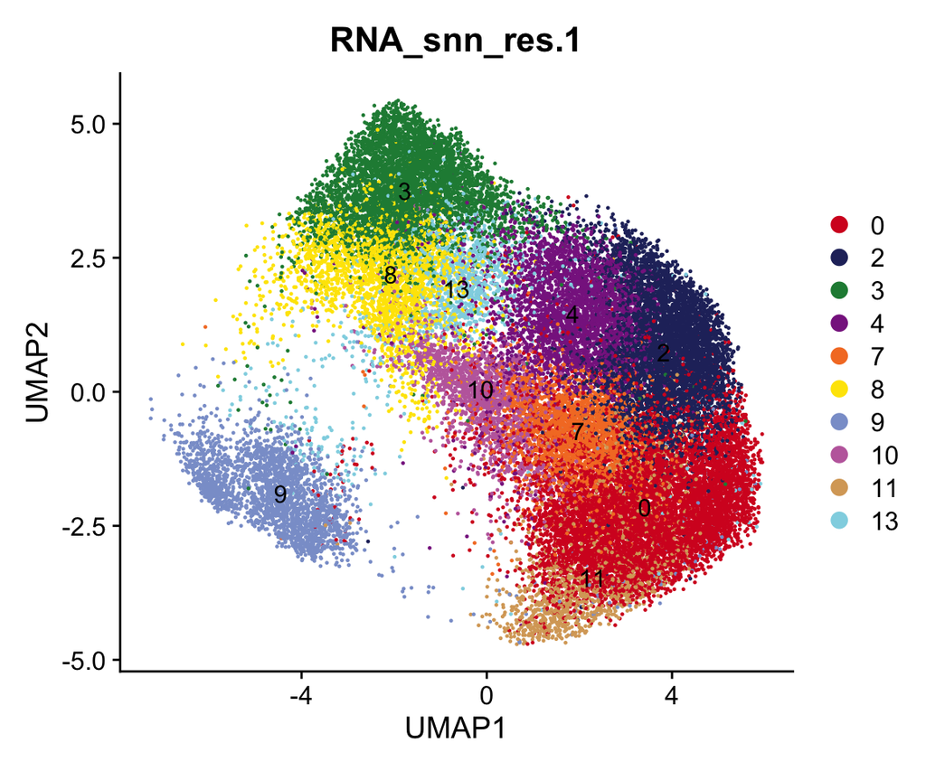

```r
cols.clusters <- ArchR::paletteDiscrete(coembed.sub[[]][, "RNA_snn_res.1"])

options(repr.plot.height = 6, repr.plot.width = 6)

p <- DimPlot(coembed.sub, group.by = "RNA_snn_res.1", label = TRUE,
             reduction = "umap_harmony", shuffle = TRUE, cols = cols.clusters) +
    xlab("UMAP1") + ylab("UMAP2")

p
```

We then re-do the UMAP embedding and clustering with a lower resolution to reduce complexity.

```r
coembed.sub <- RunUMAP(coembed.sub,
               dims = 1:30,
               reduction = 'harmony',
               reduction.name = "umap_harmony",
               reduction.key = 'umap_harmony_',
              verbose = FALSE,
                   min.dist = 0.4)
## re-clustering
coembed.sub <- FindNeighbors(coembed.sub, reduction = "harmony", dims = 1:30)
```

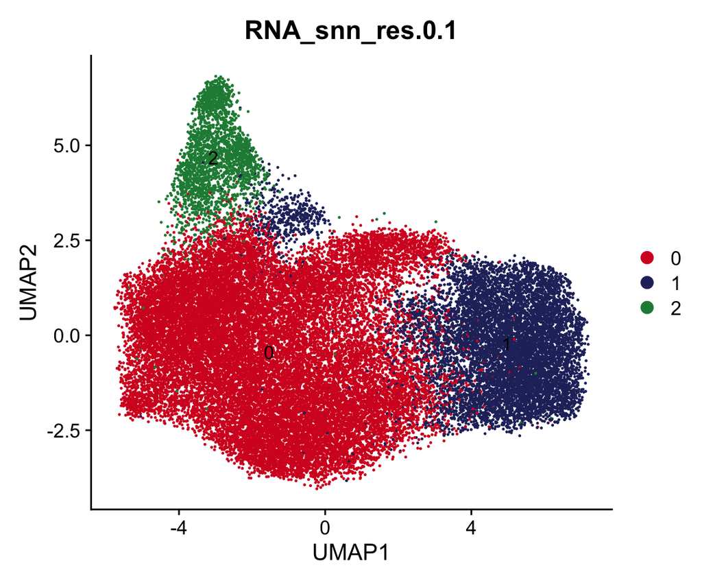

```r
coembed.sub <- FindClusters(coembed.sub, resolution = 0.1, verbose = FALSE)

cols <- ArchR::paletteDiscrete(coembed.sub[[]][, "RNA_snn_res.0.1"])

p <- DimPlot(coembed.sub, group.by = "RNA_snn_res.0.1", label = TRUE,
             reduction = "umap_harmony", shuffle = TRUE, cols = cols) +
    xlab("UMAP1") + ylab("UMAP2")

p
```

Marker genes are identified based on new clustering results and we can plot the top 10 markers.

```r
all.markers <- FindAllMarkers(coembed.sub,
                              only.pos = TRUE,
                              min.pct = 0.25, logfc.threshold = 0.5)
```

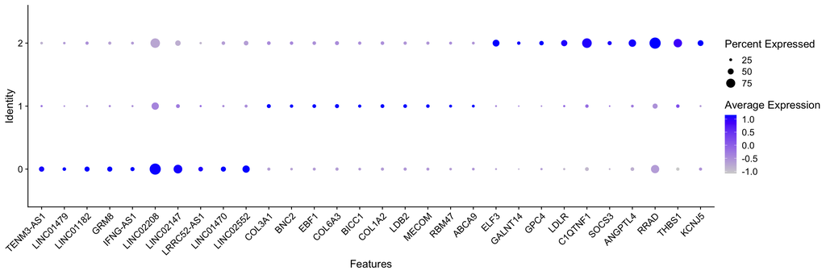

```r
df <- all.markers %>%
    group_by(cluster) %>%
    slice_max(n = 10, order_by = avg_log2FC)

p <- DotPlot(coembed.sub, features = unique(df$gene)) + RotatedAxis()
print(p)
```

```r
saveRDS(coembed.sub, "./Cardiomyocyte/coembed.cluster.rds")
```

We can plot the snRNA-seq and snATAC-seq data separately

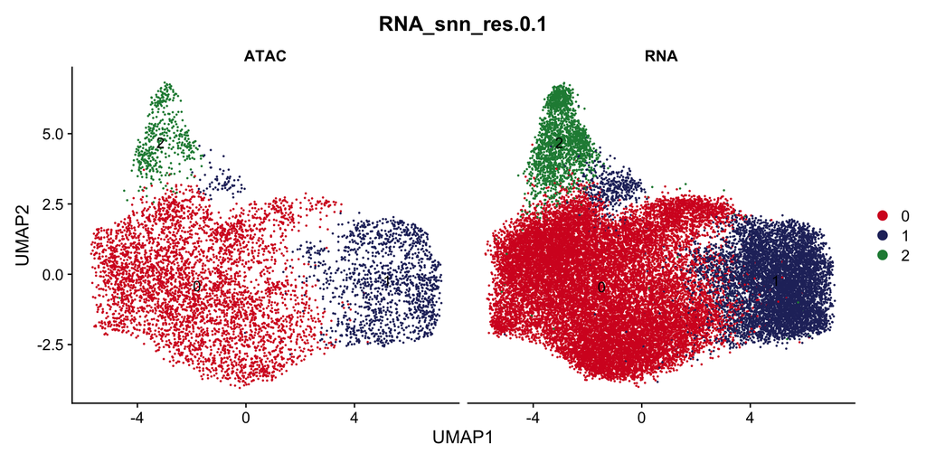

```r
p <- DimPlot(coembed.sub, group.by = "RNA_snn_res.0.1", label = TRUE,
             reduction = "umap_harmony", shuffle = TRUE, split.by = "tech",
             cols = cols) +
    xlab("UMAP1") + ylab("UMAP2")

p
```

Visualize the cell proportion of each sub-population across all patients

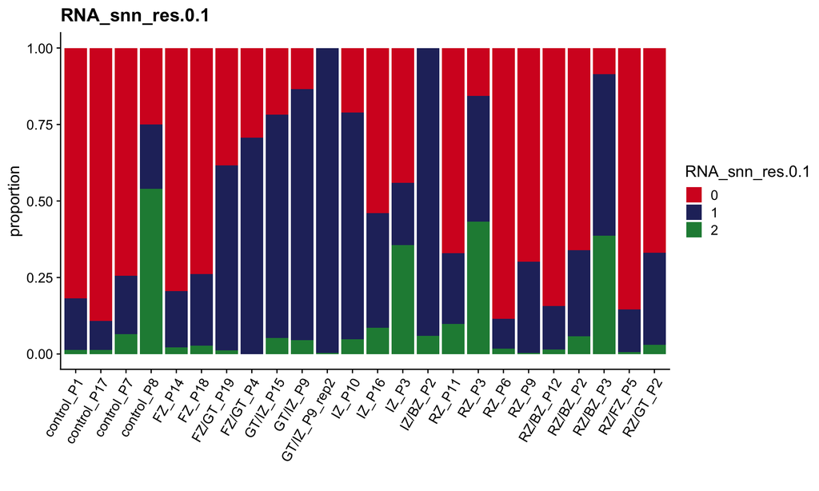

```r
p <- CellPropPlot(coembed.sub,
                   group.by = "RNA_snn_res.0.1",
                   prop.in = "patient_region_id",
                   cols = cols)

p
```

We have annotated all patients into three major groups: myogenic, ischemic, and fibrotic. we can also perform statistical test to check if any sub-population are enriched in any of the above group. This can be done by the function *CompareCellProp*.

```r
coembed.sub$patient_group <- factor(coembed.sub$patient_group,
                                    levels = c("myogenic", "ischemic", "fibrotic"))

p <- CompareCellProp(object = coembed.sub,
                     group.by = "RNA_snn_res.0.1",
                     prop.in = "patient_region_id",
                      sample.annotation = "patient_group",
                    comparisons = list(c("myogenic", "ischemic"),
                                       c("ischemic", "fibrotic"),
                                       c("myogenic", "fibrotic")))
```

```
## `stat_compare_means()` with `comparisons` displays *unadjusted* p-values (no correction for multiple comparisons).
## ℹ For p-values adjusted for multiple comparisons, use `geom_pwc()`, or `stat_pvalue_manual()` together with `compare_means(..., p.adjust.method = )`.
```

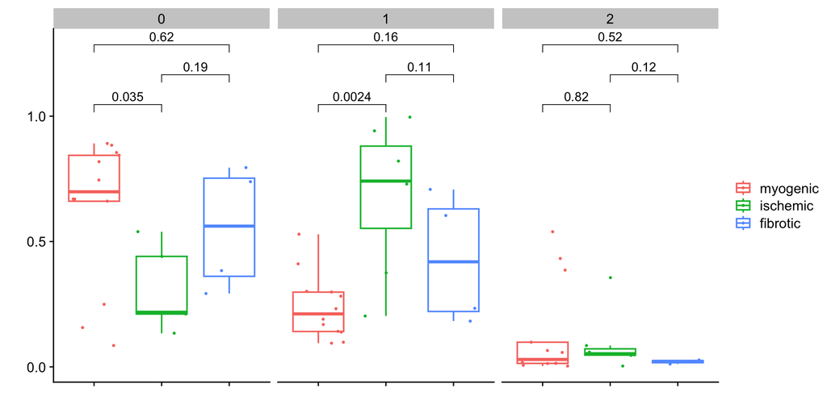

```r
p
```

Save data

```r
saveRDS(coembed.sub, "./Cardiomyocyte/coembed.sub.rds")
```

Next, we will use the integrated snRNA-seq and snATAC-seq data to infer a gene regulatory network to characterize cardiomyocyte remodeling.

More specifically, we will:

- Identify a trajectory for cardiomyocyte remodeling
- Select the relevant TFs and genes for this process
- Infer and visualize the gene regulatory network

We first load the integrated data:

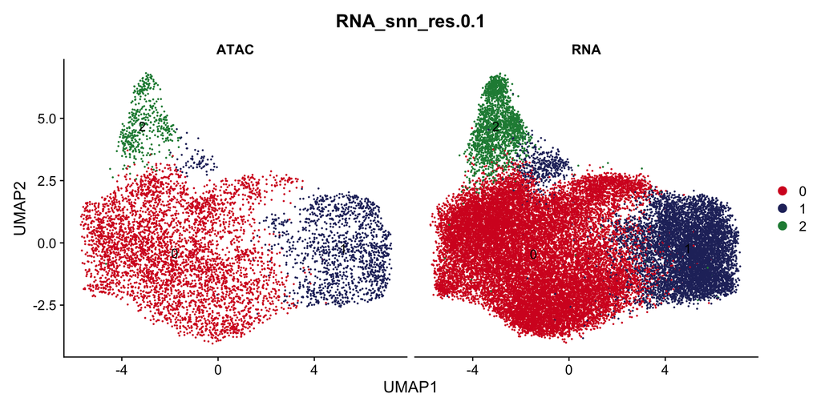

```r
coembed.sub <- readRDS("./Cardiomyocyte/coembed.sub.rds")

cols <- ArchR::paletteDiscrete(coembed.sub[[]][, "RNA_snn_res.0.1"])

p <- DimPlot(coembed.sub, group.by = "RNA_snn_res.0.1", label = TRUE,
             reduction = "umap_harmony", shuffle = TRUE, split.by = "tech",
             cols = cols) +
    xlab("UMAP1") + ylab("UMAP2")

p
```

## Trajectory analysis

### Cell pairing

We can match the cells between these two modalities. In other words, for each cell in, for example, snATAC-seq, we will find a cell from snRNA-seq data so that these two cells have the similar profiles. This is only necessary when each modality was performed independently. **If snRNA-seq and snATAC-seq data was generated by multi-modal protocol, e.g., 10X multiome or SHARE-seq, this step can be skipped.**

```r
df.pair <- PairCells(object = coembed.sub, reduction = "harmony",
                    pair.by = "tech", ident1 = "ATAC", ident2 = "RNA")
```

```
## Getting dimensional reduction data for pairing cells...
```

```
## ATAC assay doesn't leave any cells, so it is removed
```

```
## GeneActivity assay doesn't leave any cells, so it is removed
```

```
## Number of ATAC cells: 6056, number of RNA cells: 28146
```

```
## Pairing cells using greedy mode...
```

```
## [1] "Pairing all ATAC cells to nearest RNA cells"
```

```
## Finished!
```

We can visualize the paired cells

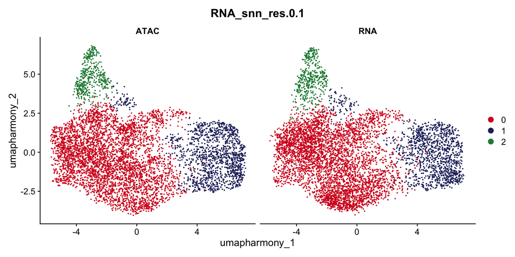

```r
sel_cells <- c(df.pair$ATAC, df.pair$RNA)
coembed.sub2 <- coembed.sub[, sel_cells]

options(repr.plot.height = 5, repr.plot.width = 10)
DimPlot(coembed.sub2, reduction = "umap_harmony",
        group.by = "RNA_snn_res.0.1", split.by = "tech", cols = cols)
```

We next create a new Seurat object for those paired cells as if they are generated by single-cell multimodal protocol.

```r
obj.pair <- CreatePairedObject(df.pair = df.pair,
                               obj.coembed = coembed.sub2,
                               obj.rna = obj.rna,
                               obj.atac = obj.atac,
                               rna.assay = "RNA",
                               atac.assay = "ATAC")
```

```
## Merging objects...
```

```r
obj.pair <- NormalizeData(obj.pair)
```

```
## Normalizing layer: counts
```

```r
obj.pair
```

```
## An object of class Seurat
## 211049 features across 6056 samples within 2 assays
## Active assay: RNA (28933 features, 0 variable features)
##  2 layers present: counts, data
##  1 other assay present: ATAC
##  4 dimensional reductions calculated: pca, umap, harmony, umap_harmony
```

Finally, we infer a pseudotime trajectory across the selected cardiomyocyte remodeling clusters using the approach from [ArchR](https://www.archrproject.com/), adapted here for a Seurat object.

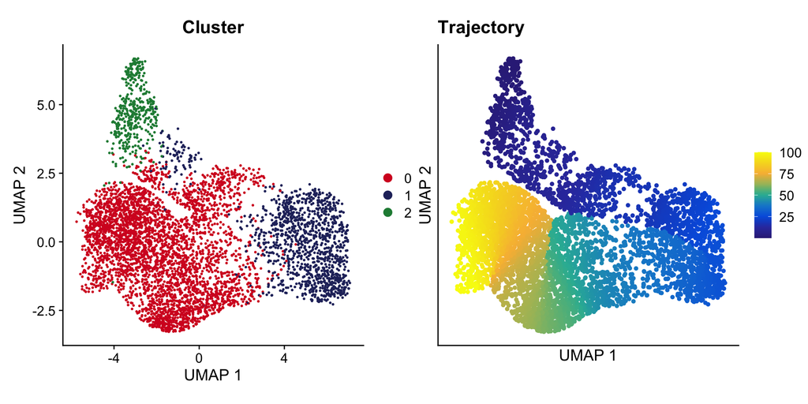

```r
obj.pair <- AddTrajectory(object = obj.pair,
                          trajectory = c(2, 1, 0),
                          group.by = "RNA_snn_res.0.1",
                          reduction = "umap_harmony",
                          dims = 1:2,
                          use.all = TRUE)

# we only plot the cells that are in this trajectory
obj <- obj.pair[, !is.na(obj.pair$Trajectory)]

p1 <- DimPlot(obj, reduction = "umap_harmony",
              group.by = "RNA_snn_res.0.1", cols = cols) +
              xlab("UMAP 1") + ylab("UMAP 2") +
    ggtitle("Cluster")


p2 <- TrajectoryPlot(object = obj,
                    reduction = "umap_harmony",
                    continuousSet = "blueYellow",
                    size = 1,
                   addArrow = FALSE) +
    xlab("UMAP 1") + ylab("UMAP 2") +
    ggtitle("Trajectory")
p1 + p2
```

## TF and gene selection

We next select candidate TFs and genes for building a meaningful gene regulatory network.

### Select TFs

To identify potential regulator (i.e., TFs), we first estimate an acitivty score for each TF in each cell. This is done by first performing motif matching and then computing deviation scores using [chromVAR](https://greenleaflab.github.io/chromVAR/index.html).

Signac 1.17 removed its `RunChromVAR()` wrapper. The code below uses the same public chromVAR steps directly while retaining the motif and peak identifiers.

```r
# Get a list of motif position frequency matrices from the JASPAR database
pfm <- getMatrixSet(
  x = JASPAR2020,
  opts = list(collection = "CORE", tax_group = 'vertebrates', all_versions = FALSE)
)

# add motif information
obj <- AddMotifs(
  object = obj,
  genome = BSgenome.Hsapiens.UCSC.hg38,
  pfm = pfm,
    assay = "ATAC"
)
```

```
## Building motif matrix
```

```
## Finding motif positions
```

```
## Creating Motif object
```

```r
run_chromvar_public <- function(object, genome, assay = "ATAC") {
  motif.matrix <- Signac::GetMotifData(object[[assay]], slot = "data")
  peak.matrix <- SeuratObject::LayerData(
    object = object, assay = assay, layer = "counts"
  )
  if (!all(peak.matrix@x == floor(peak.matrix@x)))
    warning("chromVAR expects integer counts")
  keep <- Matrix::rowSums(peak.matrix) > 0
  chromvar.object <- SummarizedExperiment::SummarizedExperiment(
    assays = list(counts = peak.matrix[keep, , drop = FALSE]),
    rowRanges = GenomicRanges::granges(object[[assay]])[keep]
  )
  chromvar.object <- chromVAR::addGCBias(chromvar.object, genome = genome)
  row.data <- as.data.frame(SummarizedExperiment::rowData(chromvar.object))
  row.data[is.na(row.data)] <- 0
  SummarizedExperiment::rowData(chromvar.object) <- row.data
  background <- chromVAR::getBackgroundPeaks(chromvar.object)
  deviations <- chromVAR::computeDeviations(
    chromvar.object,
    annotations = motif.matrix[keep, , drop = FALSE],
    background_peaks = background
  )
  z <- SummarizedExperiment::assays(deviations)[[2]]
  rownames(z) <- colnames(motif.matrix)
  object[["chromvar"]] <- SeuratObject::CreateAssayObject(data = z)
  object
}

obj <- run_chromvar_public(
  object = obj,
  genome = BSgenome.Hsapiens.UCSC.hg38,
    assay = "ATAC"
)
```

```r
res <- SelectTFs(object = obj, return.heatmap = TRUE,
cor.cutoff = 0.1)
```

```
## Creating Trajectory Group Matrix..
```

```
## Some values are below 0, this could be the Motif activity matrix in which scaleTo should be set = NULL.
## Continuing without depth normalization!
```

```
## Smoothing...
```

```
## Creating Trajectory Group Matrix..
```

```
## Smoothing...
```

```
## Find 456 shared features!
```

```r
df.cor <- res$tfs
ht <- res$heatmap
```

We can visualize the TF activity dynamic along the trajectory

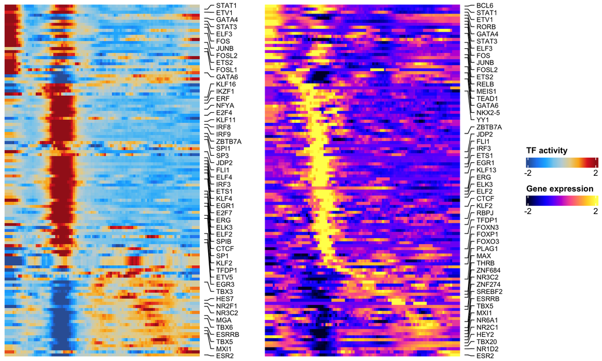

```r
draw(ht)
```

### Select genes

We will select relevant genes by first linking genes to peaks based on the corrleation between gene expression from the snRNA-seq data and peak accessibility from the snATAC-seq data along the inferred trajectory. This means that we only consider a gene to be a potential target if it can be assocaited to at least one peak.

```r
res <- SelectGenes(object = obj,
                  labelTop1 = 0,
                  labelTop2 = 0)
```

```
## Creating Trajectory Group Matrix..
```

```
## Smoothing...
```

```
## Creating Trajectory Group Matrix..
```

```
## Smoothing...
```

```
## Linking cis-regulatory elements to genes...
```

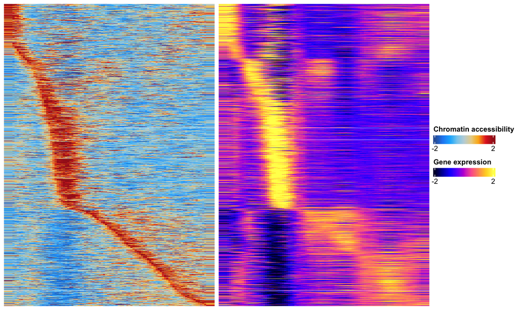

```r
df.p2g <- res$p2g
ht <- res$heatmap

draw(ht)
```

## Gene regulatory network inference and visualization

We here will try to predict a gene regulatory network based on the correlation of the TF binding activity as estimated from snATAC-seq and gene expression as measured by snRNA-seq along the trajectory.

```r
tf.gene.cor <- GetTFGeneCorrelation(object = obj,
                                    tf.use = df.cor$tfs,
                                    gene.use = unique(df.p2g$gene),
                                    tf.assay = "chromvar",
                                    gene.assay = "RNA",
                                    trajectory.name = "Trajectory")
```

```
## Creating Trajectory Group Matrix..
```

```
## Some values are below 0, this could be the Motif activity matrix in which scaleTo should be set = NULL.
## Continuing without depth normalization!
```

```
## Smoothing...
```

```
## Creating Trajectory Group Matrix..
```

```
## Smoothing...
```

We can then visualize this correlation matrix by heatmap. Also, we can cluster the genes and TFs to identify different regulatory modules for the predefined sub-populations.

```r
ht <- GRNHeatmap(tf.gene.cor,
                 tf.timepoint = df.cor$time_point)
```

```
## `use_raster` is automatically set to TRUE for a matrix with more than
## 2000 rows. You can control `use_raster` argument by explicitly setting
## TRUE/FALSE to it.
##
## Set `ht_opt$message = FALSE` to turn off this message.
```

```
## 'magick' package is suggested to install to give better rasterization.
##
## Set `ht_opt$message = FALSE` to turn off this message.
```

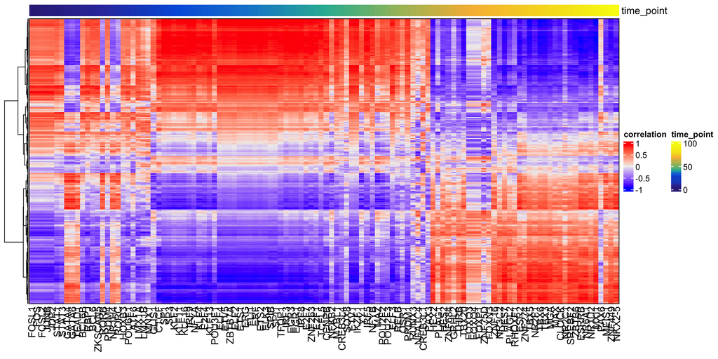

```r
ht
```

To associate genes to TFs, we will use the peak-to-gene links and TF binding sites information. Specifically, if a gene is regulated by a peak and this peak is bound by a TF, then we consider this gene to be a target of this TF.

```r
motif.matching <- Signac::GetMotifData(obj[["ATAC"]], slot = "data")
colnames(motif.matching) <- unname(unlist(
  Signac::GetMotifData(obj[["ATAC"]], slot = "motif.names"),
  use.names = FALSE
))
motif.matching <-
    motif.matching[unique(df.p2g$peak), unique(tf.gene.cor$tf)]


df.grn <- GetGRN(motif.matching = motif.matching,
                 df.cor = tf.gene.cor,
                 df.p2g = df.p2g)
```

```
## Filtering network by peak-to-gene links...
```

```
## Filtering network by TF binding site prediction...
```

Finally, we can visualize our network as the last step of this analysis

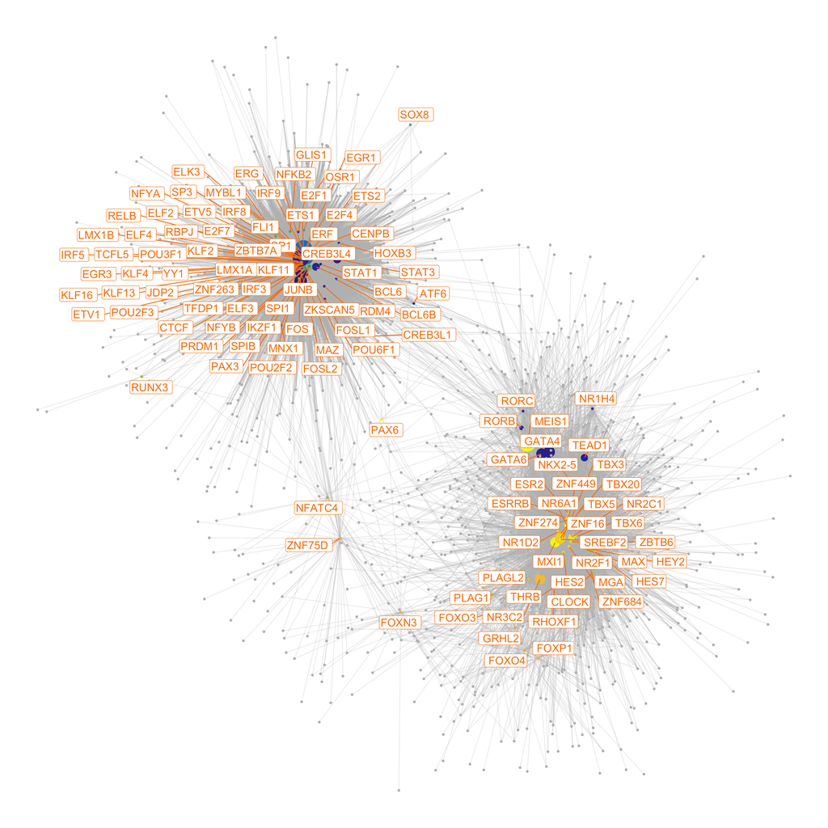

```r
# define colors for nodes representing TFs (i.e., regulators)
df.cor <- df.cor[order(df.cor$time_point), ]
tfs.timepoint <- df.cor$time_point
names(tfs.timepoint) <- df.cor$tfs

# plot the graph, here we can highlight some genes
df.grn2 <- df.grn %>%
    subset(correlation > 0.5) %>%
    select(c(tf, gene, correlation)) %>%
    rename(weights = correlation)

p <- GRNPlot(df.grn2,
             tfs.timepoint = tfs.timepoint,
             show.tf.labels = TRUE,
             seed = 42,
             plot.importance = FALSE,
            min.importance = 2,
            remove.isolated = FALSE)

options(repr.plot.height = 20, repr.plot.width = 20)

print(p)
```

Save data

```r
saveRDS(obj, "./Cardiomyocyte/coembed.trajectory.rds")
saveRDS(df.grn2, "./Cardiomyocyte/final_grn.rds")
```